# Modelo Predictivo de Déficit Habitacional: Enfoque de Redes Neuronales

Felipe Segovia y Tomás Urrutia

2026-01-09

## 1. Planteamiento del Problema y Justificación

La necesidad de implementar nuevas metodologías predictivas en el ámbito habitacional surge de tres limitaciones críticas identificadas en el sistema de medición tradicional, basándonos tanto en el análisis de la serie CASEN realizado por Larraín, Torres y Ketterer (2023) como en los reportes oficiales del Ministerio de Desarrollo Social y Familia (2023).

### 1.1. Carácter Estático y Reactivo de la Medición

El sistema actual mide el déficit habitacional como una variable de *stock*, lo que genera una falsa sensación de estabilidad. Si bien la nueva metodología oficial ajusta el déficit a **552.046 viviendas** para 2022, esta cifra agregada esconde dinámicas internas críticas:

- **El predominio del allegamiento:** Los datos oficiales confirman que los hogares allegados se han consolidado como el componente más importante del déficit, representando más de **277.000 casos** en 2022 (MDSF, 2023).
- **La “ceguera” ante campamentos:** Aunque los catastros del MINVU reportan un alza significativa de hogares en campamentos (llegando a 71.961 en 2022), el reporte oficial de CASEN reconoce explícitamente que *“su diseño muestral no tiene entre sus objetivos generar datos representativos para dicho grupo de la población”* (MDSF, 2023). Esto confirma que la herramienta principal (CASEN) es estructuralmente “reactiva” e insuficiente para monitorear la precariedad más extrema en tiempo real.

### 1.2. “Ceguera Espacial”: La Divergencia Territorial

Las metodologías tradicionales tienden a asumir una homogeneidad territorial, sufriendo de una “ceguera” ante la concentración geográfica de la crisis. El informe de Resultados Casen 2022 confirma que, aunque el déficit es numéricamente mayor en la RM, la **intensidad del problema** (prevalencia) está severamente concentrada en el norte:

- **Zona Norte (Crisis de Intensidad):** Las regiones con mayor prevalencia de déficit respecto a su población son **Tarapacá (14,3%)**, **Arica y Parinacota (13,5%)** y **Antofagasta (11,3%)**. De hecho, Arica y Parinacota fue la única región que aumentó su déficit de manera estadísticamente significativa entre 2017 y 2022 (MDSF, 2023).
- **Zona Sur (Tendencia a la baja):** En contraste, regiones como Coquimbo y Biobío mostraron las mayores reducciones del déficit en el mismo período.

Esta disparidad, validada por los datos oficiales, justifica la necesidad de integrar variables territoriales (IDE MINVU) en el modelo, ya que un algoritmo “ciego” al territorio no puede explicar estas divergencias regionales extremas.

### 1.3. Falta de Anticipación: La Variable Oculta de la Fragilidad

Finalmente, los métodos actuales carecen de capacidad anticipatoria al ignorar la **“Asequibilidad”** o Fragilidad Habitacional. El reporte oficial define la asequibilidad como el porcentaje de hogares que gastan más del 30% de su ingreso en vivienda, un indicador que ha mostrado un deterioro alarmante:

1. **Duplicación del Problema:** El porcentaje de hogares con problemas de asequibilidad prácticamente se ha duplicado en la última década, pasando del 6,9% en 2011 al **13,7% en 2022** (MDSF, 2023).
2. **Volumen de Afectados:** Esto se traduce en **956.185 hogares** a nivel nacional que hoy enfrentan una carga financiera crítica, una cifra que supera ampliamente al déficit cuantitativo físico (552.046).

Este grupo constituye la “demanda oculta” del sistema. Al no incorporar esta variable de flujo financiero, los modelos tradicionales fallan en predecir qué hogares, hoy técnicamente “sanos”, caerán mañana en déficit material por incapacidad de pago (Larraín et al., 2023).

## 2. Pregunta de Investigación y Variables de Estudio

### 2.1. Pregunta de Investigación

*“¿En qué medida un modelo de Inteligencia Artificial (Deep Learning), que integre los microdatos socioeconómicos del hogar (CASEN 2022) con variables de presión territorial (IDE MINVU), permite clasificar correctamente a los hogares en situación de **Déficit Habitacional Cuantitativo** en comparación con los métodos tradicionales que ignoran el entorno?”*

### 2.2. Operacionalización de la Variable Objetivo (Target)

Para efectos del modelamiento predictivo, se define una única variable dependiente binaria (`CLASE`), construida a partir de las reglas de negocio del Ministerio de Desarrollo Social y Familia (MDSF, 2023).

Un hogar es clasificado como **Déficit (Clase 2)** si presenta al menos una de las siguientes carencias materiales críticas detectadas en la encuesta CASEN:

1. **Hacinamiento Medio o Crítico:** Hogares que presentan 2,5 o más personas por dormitorio de uso exclusivo.
2. **Allegamiento Externo:** Hogares que comparten la vivienda con un hogar principal. Según el último reporte oficial, este componente se ha consolidado como el mayoritario dentro del déficit cuantitativo (MDSF, 2023).
3. **Vivienda Irrecuperable:** Viviendas cuya materialidad en pisos, techos o muros es considerada deficitaria según el Índice de Calidad Global de la Vivienda (MDSF, 2023).

> **Nota Metodológica:** En el script de procesamiento, todos los hogares que no cumplen con ninguna de estas tres condiciones son etiquetados como **“Sanos” (Clase 0)**.

### 2.3. Variables Predictoras (Inputs)

El modelo busca predecir esta clasificación utilizando dos niveles de información: * **Nivel Micro (Hogar):** Variables de la encuesta CASEN como ingreso autónomo, escolaridad, tamaño del hogar y jefatura femenina o inmigrante. * **Nivel Macro (Territorial):** Variables de la IDE MINVU (Déficit comunal y zonas de saturación) para incorporar el factor “espacial” al riesgo de precariedad.

## 3. Objetivos del Proyecto

### 3.1. Objetivo General

Desarrollar un modelo predictivo basado en Inteligencia Artificial (Redes Neuronales) que permita identificar y clasificar hogares en riesgo de **Déficit Habitacional Cuantitativo** y **Fragilidad Habitacional**, integrando variables socioeconómicas individuales (CASEN) con indicadores de presión territorial (MINVU) para superar las limitaciones de “ceguera espacial” de las mediciones actuales.

### 3.2. Objetivos Específicos

1. **Integración Multidimensional de Datos (ETL):** Construir un dataset consolidado que homologue la información micro-social de la Encuesta CASEN 2022 con los datos geoespaciales de la IDE MINVU, resolviendo la incompatibilidad de formatos territoriales para enriquecer la caracterización del entorno de cada hogar.
2. **Entrenamiento y Balanceo del Modelo:** Entrenar un algoritmo de *Deep Learning* (Perceptrón Multicapa) capaz de detectar patrones no lineales de vulnerabilidad. Se implementarán técnicas de *Up-Sampling* para corregir el desbalance de clases inherente al problema, asegurando que el modelo aprenda a identificar correctamente a la minoría afectada (hogares en déficit) y no solo a la mayoría sana.
3. **Detección de Nuevos Perfiles de Riesgo:** Evaluar la capacidad del modelo para identificar la “Demanda Oculta” o Fragilidad Habitacional, determinando qué peso tienen las nuevas variables demográficas (como la jefatura inmigrante o los hogares unipersonales) y las variables territoriales en la probabilidad de caer en precariedad habitacional.

## 4. Metodología: Ingeniería de Datos

Para entrenar el modelo predictivo, se implementó un flujo de trabajo de tres etapas diseñado para asegurar la calidad estadística de la muestra y la correcta integración de las variables territoriales.

### 4.1. Integración de Fuentes (Data Merging)

El primer desafío técnico fue enriquecer la caracterización socioeconómica (CASEN) con la realidad territorial (MINVU). Dado que ambas fuentes utilizan formatos distintos para los códigos comunales (números vs. texto), se estandarizaron las llaves primarias mediante el Código Único Territorial (CUT).

## 4. Metodología

Para entrenar el modelo predictivo, se implementó un flujo de trabajo de tres etapas diseñado para asegurar la calidad estadística de la muestra y la correcta integración de las variables territoriales.

### 4.1. Integración de Fuentes (Data Merging)

El primer desafío técnico fue enriquecer la caracterización socioeconómica (CASEN) con la realidad territorial (MINVU). Dado que ambas fuentes utilizan formatos distintos para los códigos comunales (números vs. texto), se estandarizaron las llaves primarias mediante el Código Único Territorial (CUT).

```r
library(tidyverse)
library(stringr) # Para estandarización de texto
library(sf)      # Para manejo de datos espaciales
library(haven)   # Para leer SPSS

# NOTA METODOLÓGICA:
# Este código se presenta para demostrar el proceso de integración realizado.
# Para efectos de esta presentación, cargaremos directamente la base consolidada.

# 1. Carga de fuentes originales
# casen_raw <- read_sav("Base de datos provincia y comuna Casen 2022 SPSS.sav")
# mapa_minvu <- st_read("CECYT_DEFICIT_HABIT_2023_WM.shp")

# 2. Ingeniería de Datos: Estandarización de Llave Maestra (CUT)
# casen_prep <- casen_raw %>%
#   mutate(codigo_cruce = str_pad(as.character(comuna), width = 5, side = "left", pad = "0"))

# mapa_prep <- mapa_minvu %>%
#   st_drop_geometry() %>%
#   mutate(codigo_cruce = str_pad(as.character(COMUNA), width = 5, side = "left", pad = "0"))

# 3. El Cruce (Merge)
# dataset_integrado <- left_join(casen_prep, mapa_prep, by = "codigo_cruce")
```

### 4.2. Construcción de la Variable Objetivo (Target)

Se operacionalizó la variable dependiente `CLASE` siguiendo las reglas de negocio oficiales del Ministerio de Desarrollo Social (MDSF, 2023). Se etiquetó como **“Déficit” (Clase 2)** a cualquier hogar que presente al menos una de las siguientes carencias graves: Hacinamiento, Allegamiento Externo o Vivienda Irrecuperable.

```r
library(tidyverse)
library(haven)

# --- CARGA OPTIMIZADA DE DATOS ---
# Cargamos el archivo procesado (.rds) que ya se encuentra en el directorio.
# Esto asegura que el reporte compile rápido sin procesar la base bruta nuevamente.

if(file.exists("Base_Tesis_Lista.rds")) {
  df_raw <- readRDS("Base_Tesis_Lista.rds")
} else if(file.exists("Base_Para_Entrenar_Red_Neuronal.rds")) {
  df_raw <- readRDS("Base_Para_Entrenar_Red_Neuronal.rds")

}

# OPERACIONALIZACIÓN DE LA VARIABLE DEPENDIENTE
# Aplicamos las reglas de clasificación sobre la base cargada
df_etiquetado <- df_raw %>%
  mutate(
    # Aseguramos que las variables sean numéricas para evitar errores de cálculo
    ind_hacina = as.numeric(ind_hacina),
    allega_ext = as.numeric(allega_ext),
    # Si la variable materialidad no existe en la versión resumida, asumimos 0 (Sano)
    ind_mat = if("ind_mat" %in% names(.)) as.numeric(ind_mat) else 0
  ) %>%
  mutate(
    # Creación de la Etiqueta de Clase (Target)
    CLASE = case_when(
      ind_hacina >= 2 ~ 2,        # Criterio 1: Hacinamiento Medio (2.5+) o Crítico (5+)
      allega_ext == 1 ~ 2,        # Criterio 2: Allegamiento Externo
      ind_mat == 3 ~ 2,           # Criterio 3: Vivienda Irrecuperable (si aplica)
      TRUE ~ 0                    # Resto: Hogares "Sanos" (Clase 0)
    )
  )

# Verificación de Resultados
print("Distribución de Clases Generada (0=Sano, 2=Déficit):")
```

```
## [1] "Distribución de Clases Generada (0=Sano, 2=Déficit):"
```

```r
table(df_etiquetado$CLASE)
```

```
##
##      0      2
## 185942  16289
```

### 4.3. Definición de la Unidad de Análisis y Selección Final

La encuesta CASEN es una base de datos a nivel de individuos. Sin embargo, el déficit habitacional es un atributo del **Hogar**. Incluir a todos los integrantes duplicaría la información y generaría autocorrelación.

```r
# 1. FILTRO DE UNIDAD DE ANÁLISIS
# Seleccionamos un solo representante por hogar (Jefe de Hogar / Folio Único)
# Nota: 'df_etiquetado' viene del bloque anterior (4.2)
df_hogares <- df_etiquetado %>%
  distinct(folio, .keep_all = TRUE)

# 2. SELECCIÓN DE PREDICTORES (Feature Selection)
# Definimos las variables que entrarán al modelo
vars_posibles <- c("folio", "CLASE", "yautcor", "tot_per_h", "esc", "edad", "sexo",
                   "deficit_cuantitativo_total", "ind_hacina")

# Creamos la tabla final 'df_final_modelo' (ESTA ES LA QUE PIDE EL BLOQUE 5)
df_final_modelo <- df_hogares %>%
  select(any_of(vars_posibles)) %>%
  na.omit() # Eliminamos datos vacíos

# Verificación
print(paste("Hogares finales para el modelo:", nrow(df_final_modelo)))
```

```
## [1] "Hogares finales para el modelo: 56346"
```

```r
head(df_final_modelo)
```

```
## # A tibble: 6 × 9
##       folio CLASE yautcor tot_per_h   esc  edad sexo      deficit_cuantitativo…¹
##       <dbl> <dbl>   <dbl>     <dbl> <dbl> <dbl> <dbl+lbl>                  <dbl>
## 1 100090101     0   10000         3     1    72 2 [2. Mu…                     11
## 2 100090301     0   60000         3     4    84 1 [1. Ho…                     11
## 3 100090401     0  590000         2     5    64 1 [1. Ho…                     11
## 4 100090501     0  130000         1     5    59 2 [2. Mu…                     11
## 5 100090601     0  520000         4    12    34 1 [1. Ho…                     11
## 6 100090901     0  160000         1    10    68 2 [2. Mu…                     11
## # ℹ abbreviated name: ¹deficit_cuantitativo_total
## # ℹ 1 more variable: ind_hacina <dbl>
```

### 4.4. Exploración Visual de la Variable Objetivo

Antes de proceder al modelamiento, es crucial diagnosticar el balance de clases. Visualizamos la distribución de la variable dependiente para confirmar la asimetría de la muestra.

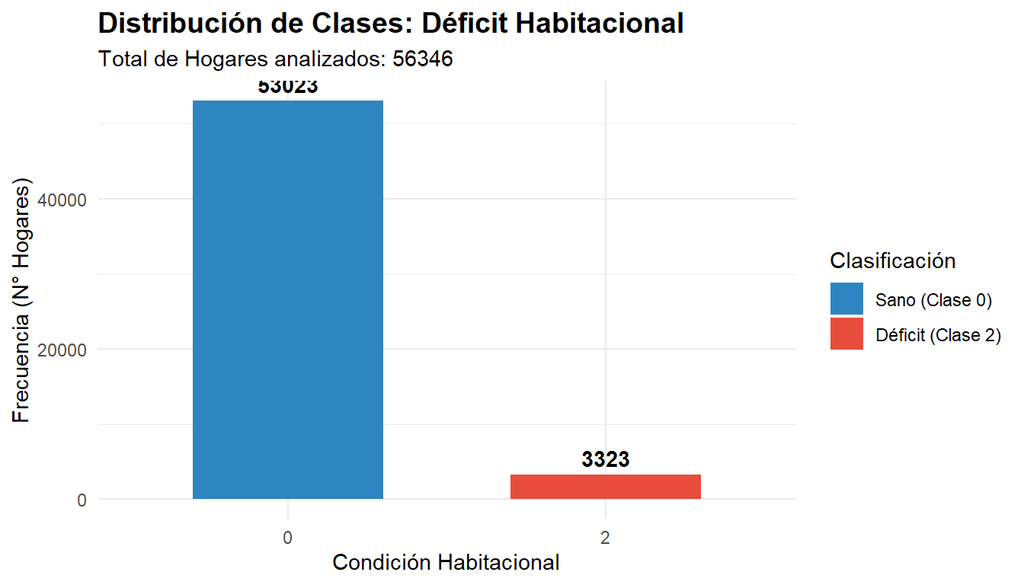

```r
library(ggplot2)

# Generamos un gráfico de barras para evidenciar el desbalance
ggplot(df_final_modelo, aes(x = as.factor(CLASE), fill = as.factor(CLASE))) +
  geom_bar(width = 0.6) +
  # Definición de colores: Azul corporativo (Sano) y Rojo alerta (Déficit)
  scale_fill_manual(values = c("0" = "#2E86C1", "2" = "#E74C3C"),
                    labels = c("Sano (Clase 0)", "Déficit (Clase 2)")) +
  labs(title = "Distribución de Clases: Déficit Habitacional",
       subtitle = paste("Total de Hogares analizados:", nrow(df_final_modelo)),
       x = "Condición Habitacional",
       y = "Frecuencia (N° Hogares)",
       fill = "Clasificación") +
  # Agregamos las etiquetas de datos sobre las barras
  geom_text(aes(label = after_stat(count)), stat = "count", vjust = -0.5, fontface = "bold") +
  theme_minimal() +
  theme(plot.title = element_text(face = "bold", size = 14))
```

## 5. Análisis Descriptivo de los Perfiles de Riesgo

Una vez consolidada la base de datos, caracterizamos los hogares para validar si los datos respaldan las hipótesis de vulnerabilidad.

### 5.1. Tabla Resumen Comparativa

Se comparan las variables clave entre hogares “Sanos” y con “Déficit” para identificar brechas estructurales.

```r
library(dplyr)
library(knitr)

# 1. Creación de la Tabla Resumen
tabla_resumen <- df_final_modelo %>%
  group_by(CLASE) %>%
  summarise(
    N = n(),
    # Calculamos promedios
    Ingreso = mean(yautcor, na.rm = TRUE),
    Personas = mean(tot_per_h, na.rm = TRUE),
    Escolaridad = mean(esc, na.rm = TRUE),
    Edad = mean(edad, na.rm = TRUE)
  ) %>%
  mutate(

    Condición = ifelse(CLASE == 2, "HOGAR EN DÉFICIT", "HOGAR SANO"),

    Ingreso = paste0("$", format(round(Ingreso, 0), big.mark=".")),
    Personas = round(Personas, 1), # 1 decimal para promedio de personas
    Escolaridad = round(Escolaridad, 1),
    Edad = round(Edad, 0)
  ) %>%
  # Seleccionamos y ordenamos columnas con nombres limpios
  select(Condición, N, Ingreso, Personas, Escolaridad, Edad)

# 2. Impresión de Tabla Estilizada
kable(tabla_resumen,
      caption = "Tabla 1: Perfil Socioeconómico Comparado",
      align = "c", # Centrar todas las columnas
      col.names = c("Condición", "Cant. Hogares", "Ingreso Promedio", "Tam. Hogar", "Escolaridad", "Edad Jefe"))
```

Tabla 1: Perfil Socioeconómico Comparado

| Condición | Cant. Hogares | Ingreso Promedio | Tam. Hogar | Escolaridad | Edad Jefe |
| --- | --- | --- | --- | --- | --- |
| HOGAR SANO | 53023 | $685.835 | 2.7 | 11.4 | 53 |
| HOGAR EN DÉFICIT | 3323 | $503.549 | 3.5 | 11.0 | 46 |

### 5.2. Visualización de la Brecha de Ingresos

El siguiente gráfico ilustra la distribución del ingreso autónomo entre ambos grupos. Se observa que la mediana de ingresos en hogares con déficit es inferior, aunque la existencia de traslape entre las cajas sugiere que el ingreso por sí solo no explica la totalidad del problema, validando la necesidad de un enfoque multidimensional.

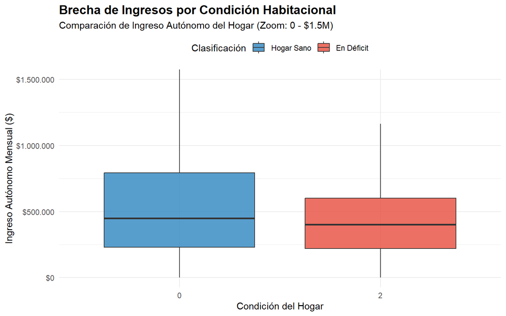

```r
library(ggplot2)

# Gráfico de Cajas (Boxplot) para comparar distribuciones
ggplot(df_final_modelo, aes(x = as.factor(CLASE), y = yautcor, fill = as.factor(CLASE))) +
  geom_boxplot(outlier.shape = NA, alpha = 0.8) + # Ocultamos outliers extremos para limpiar la vista

  # Zoom al eje Y: Cortamos en $1.5M para ver mejor el grueso de la población
  # (Sin este corte, los sueldos millonarios aplastan el gráfico)
  coord_cartesian(ylim = c(0, 1500000)) +

  # Formato de dinero en el eje Y
  scale_y_continuous(labels = scales::dollar_format(prefix="$", big.mark = ".")) +

  # Colores corporativos: Azul (Sano) vs Rojo (Déficit)
  scale_fill_manual(values = c("#2E86C1", "#E74C3C"),
                    labels = c("Hogar Sano", "En Déficit")) +

  # Etiquetas profesionales
  labs(title = "Brecha de Ingresos por Condición Habitacional",
       subtitle = "Comparación de Ingreso Autónomo del Hogar (Zoom: 0 - $1.5M)",
       x = "Condición del Hogar",
       y = "Ingreso Autónomo Mensual ($)",
       fill = "Clasificación") +

  theme_minimal() +
  theme(legend.position = "top",
        plot.title = element_text(face = "bold", size = 14))
```